# Danish Kings

Cecilie Barrett

5 MArch 2025

The task here is to load your Danish Monarchs csv into R using the `tidyverse` toolkit, calculate and explore the kings’ duration of reign with pipes `%>%` in `dplyr` and plot it over time.

## Load the kings

Make sure to first create an `.Rproj` workspace with a `data/` folder where you place either your own dataset or the provided `kings.csv` dataset.

1. Look at the dataset that are you loading and check what its columns are separated by? (hint: open it in plain text editor to see)

List what is the

separator: comma (,)

2. Create a `kings` object in R with the different functions below and inspect the different outputs.
- `read.csv()`
- `read_csv()`
- `read.csv2()`
- `read_csv2()`

```r
# FILL IN THE CODE BELOW and review the outputs
library(tidyverse)
kings1 <- read.csv("data/kings.csv")

kings2 <- read_csv(("data/kings.csv") , na=c("NULL", ""))
kings3 <- read.csv2("data/kings.csv")

kings4 <- read_csv2( "data/kings.csv")
```

```
## ℹ Using "','" as decimal and "'.'" as grouping mark. Use `read_delim()` for more control.
```

```r
class(kings2)
```

```
## [1] "spec_tbl_df" "tbl_df"      "tbl"         "data.frame"
```

Answer: 1. Which of these functions is a `tidyverse` function? Read data with it below into a `kings` object

The ones called read_csv and read_csv2 are tidyverse function and underscore defines the tidyverse one.

2. What is the result of running `class()` on the `kings` object created with a tidyverse function.

you get the definition of datasets, a tidyverse table, which is called tibble.

3. How many columns does the object have when created with these different functions?

Both functions read.csv and read_csv read the amount of columns as 11, so they read the same. The csv2 function reads only 1 column so it doesn’t work.

4. Show the dataset so that we can see how R interprets each column

```r
# COMPLETE THE BLANKS BELOW WITH YOUR CODE, then turn the 'eval' flag in this chunk to TRUE.



class(kings1)
```

```
## [1] "data.frame"
```

```r
class(kings2)
```

```
## [1] "spec_tbl_df" "tbl_df"      "tbl"         "data.frame"
```

```r
class(kings3)
```

```
## [1] "data.frame"
```

```r
class(kings4)
```

```
## [1] "spec_tbl_df" "tbl_df"      "tbl"         "data.frame"
```

```r
ncol(kings1)
```

```
## [1] 11
```

```r
ncol(kings2)
```

```
## [1] 11
```

```r
ncol(kings3)
```

```
## [1] 1
```

```r
ncol(kings4)
```

```
## [1] 1
```

```r
head(kings1)
```

```
##                Name House Start_year End_year Birth_year Death_year Gender
## 1    Gorm den Gamle  Gorm        936      958        908        958      M
## 2 Harald 1. Blåtand  Gorm       NULL     NULL        936        985     M
## 3      Toke_Gormsen  Gorm        985      986       NULL        986     M
## 4  Svend 1. Tveskæg  Gorm       NULL     NULL       NULL       1014     M
## 5         Harald 2.  Gorm       1014     1018        963       NULL     M
## 6 Knud 1. den Store  Gorm       1018     1035       NULL       1035     M
##            Dynasty                                            Source  BirthDMY
## 1 Jellingdynastiet      https://da.wikipedia.org/wiki/Gorm_den_Gamle       908
## 2 Jellingdynastiet https://da.wikipedia.org/wiki/Harald_Bl%C3%A5tand       936
## 3 Jellingdynastiet        https://da.wikipedia.org/wiki/Toke_Gormsen
## 4 Jellingdynastiet  https://da.wikipedia.org/wiki/Svend_Tvesk%C3%A6g 17/04/963
## 5 Jellingdynastiet           https://da.wikipedia.org/wiki/Harald_2.       994
## 6 Jellingdynastiet      https://da.wikipedia.org/wiki/Knud_den_Store       995
##     DeathDMY
## 1        958
## 2        987
## 3
## 4 03/02/1014
## 5       1018
## 6 12/11/1035
```

```r
head(kings2)
```

```
## # A tibble: 6 × 11
##   Name     House Start_year End_year Birth_year Death_year Gender Dynasty Source
##   <chr>    <chr>      <dbl>    <dbl>      <dbl>      <dbl> <chr>  <chr>   <chr>
## 1 Gorm de… Gorm         936      958        908        958 M      Jellin… https…
## 2 Harald … Gorm          NA       NA        936        985 M      Jellin… https…
## 3 Toke_Go… Gorm         985      986         NA        986 M      Jellin… https…
## 4 Svend 1… Gorm          NA       NA         NA       1014 M      Jellin… https…
## 5 Harald … Gorm        1014     1018        963         NA M      Jellin… https…
## 6 Knud 1.… Gorm        1018     1035         NA       1035 M      Jellin… https…
## # ℹ 2 more variables: BirthDMY <chr>, DeathDMY <chr>
```

```r
head(kings3)
```

```
##                                          Name.House.Start_year.End_year.Birth_year.Death_year.Gender.Dynasty.Source.BirthDMY.DeathDMY
## 1                         Gorm den Gamle,Gorm,936,958,908,958,M,Jellingdynastiet,https://da.wikipedia.org/wiki/Gorm_den_Gamle,908,958
## 2              Harald 1. Blåtand,Gorm,NULL,NULL,936,985,M ,Jellingdynastiet,https://da.wikipedia.org/wiki/Harald_Bl%C3%A5tand,936,987
## 3                                 Toke_Gormsen,Gorm,985,986,NULL,986,M ,Jellingdynastiet,https://da.wikipedia.org/wiki/Toke_Gormsen,,
## 4 Svend 1. Tveskæg,Gorm,NULL,NULL,NULL,1014,M ,Jellingdynastiet,https://da.wikipedia.org/wiki/Svend_Tvesk%C3%A6g,17/04/963,03/02/1014
## 5                              Harald 2.,Gorm,1014,1018,963,NULL,M ,Jellingdynastiet,https://da.wikipedia.org/wiki/Harald_2.,994,1018
## 6          Knud 1. den Store,Gorm,1018,1035,NULL,1035,M ,Jellingdynastiet,https://da.wikipedia.org/wiki/Knud_den_Store,995,12/11/1035
```

```r
head(kings4)
```

```
## # A tibble: 6 × 1
##   Name,House,Start_year,End_year,Birth_year,Death_year,Gender,Dynasty,Source,B…¹
##   <chr>
## 1 Gorm den Gamle,Gorm,936,958,908,958,M,Jellingdynastiet,https://da.wikipedia.o…
## 2 Harald 1. Blåtand,Gorm,NULL,NULL,936,985,M ,Jellingdynastiet,https://da.wikip…
## 3 Toke_Gormsen,Gorm,985,986,NULL,986,M ,Jellingdynastiet,https://da.wikipedia.o…
## 4 Svend 1. Tveskæg,Gorm,NULL,NULL,NULL,1014,M ,Jellingdynastiet,https://da.wiki…
## 5 Harald 2.,Gorm,1014,1018,963,NULL,M ,Jellingdynastiet,https://da.wikipedia.or…
## 6 Knud 1. den Store,Gorm,1018,1035,NULL,1035,M ,Jellingdynastiet,https://da.wik…
## # ℹ abbreviated name:
## #   ¹`Name,House,Start_year,End_year,Birth_year,Death_year,Gender,Dynasty,Source,BirthDMY,DeathDMY`
```

```r
kings <-kings2

glimpse(kings2)
```

```
## Rows: 57
## Columns: 11
## $ Name       <chr> "Gorm den Gamle", "Harald 1. Blåtand", "Toke_Gormsen", "Sve…
## $ House      <chr> "Gorm", "Gorm", "Gorm", "Gorm", "Gorm", "Gorm", "Gorm", "Fa…
## $ Start_year <dbl> 936, NA, 985, NA, 1014, 1018, 1035, 1042, 1047, 1074, 1080,…
## $ End_year   <dbl> 958, NA, 986, NA, 1018, 1035, 1042, 1047, 1074, 1080, 1086,…
## $ Birth_year <dbl> 908, 936, NA, NA, 963, NA, 995, 1018, 1024, 1019, 1041, 104…
## $ Death_year <dbl> 958, 985, 986, 1014, NA, 1035, 1042, 1047, 1076, 1080, 1086…
## $ Gender     <chr> "M", "M", "M", "M", "M", "M", "M", "M", "M", "M", "M", "M",…
## $ Dynasty    <chr> "Jellingdynastiet", "Jellingdynastiet", "Jellingdynastiet",…
## $ Source     <chr> "https://da.wikipedia.org/wiki/Gorm_den_Gamle", "https://da…
## $ BirthDMY   <chr> "908", "936", NA, "17/04/963", "994", "995", "1018", "1024"…
## $ DeathDMY   <chr> "958", "987", NA, "03/02/1014", "1018", "12/11/1035", "08/0…
```

## Calculate the duration of reign for all the kings in your table

You can calculate the duration of reign in years with `mutate` function by subtracting the equivalents of your `startReign` from `endReign` columns and writing the result to a new column called `duration`. But first you need to check a few things:

- Is your data messy? Fix it before re-importing to R
- Do your start and end of reign columns contain NAs? Choose the right strategy to deal with them: `na.omit()`, `na.rm=TRUE`, `!is.na()`

Create a new column called `duration` in the kings dataset, utilizing the `mutate()` function from tidyverse. Check with your group to brainstorm the options.

```r
# YOUR CODE
kingsduration <- kings2 %>%
  mutate(duration=End_year-Start_year)

kingsduration %>%
  select(duration)
```

```
## # A tibble: 57 × 1
##    duration
##       <dbl>
##  1       22
##  2       NA
##  3        1
##  4       NA
##  5        4
##  6       17
##  7        7
##  8        5
##  9       27
## 10        6
## # ℹ 47 more rows
```

## Calculate the average duration of reign for all rulers

Do you remember how to calculate an average on a vector object? If not, review the last two lessons and remember that a column is basically a vector. So you need to subset your `kings` dataset to the `duration` column. If you subset it as a vector you can calculate average on it with `mean()` base-R function. If you subset it as a tibble, you can calculate average on it with `summarize()` tidyverse function. Try both ways!

- You first need to know how to select the relevant `duration` column. What are your options?
- Is your selected `duration` column a tibble or a vector? The `mean()` function can only be run on a vector. The `summarize()` function works on a tibble.
- Are you getting an error that there are characters in your column? Coerce your data to numbers with `as.numeric()`.
- Remember to handle NAs: `mean(X, na.rm=TRUE)`

```r
# YOUR CODE
kingsduration <- kings2%>%
  mutate(duration= End_year - Start_year)
kingsduration[["duration"]]
```

```
##  [1] 22 NA  1 NA  4 17  7  5 27  6  6  9  8 30  3  9 11 25 20 39  9  2  7 27 33
## [26]  7  3  3 35 12  9 43  8 33 31 10 10 23 29 60 22 29 31 16 20 42 31  9 15 43
## [51]  6 35 25 51 NA NA NA
```

```r
mean(kingsduration[["duration"]], na.rm=TRUE)
```

```
## [1] 19.57692
```

```r
avgduration <- mean(kingsduration[["duration"]], na.rm=TRUE)
```

## How many and which kings enjoyed a longer-than-average duration of reign?

You have calculated the average duration above. Use it now to `filter()` the `duration` column in `kings` dataset. Display the result and also count the resulting rows with `count()`

```r
# YOUR CODE

filtered_kings <- kingsduration %>%
  filter(duration > avgduration)

filtered_kings
```

```
## # A tibble: 25 × 12
##    Name    House Start_year End_year Birth_year Death_year Gender Dynasty Source
##    <chr>   <chr>      <dbl>    <dbl>      <dbl>      <dbl> <chr>  <chr>   <chr>
##  1 Gorm d… Gorm         936      958        908        958 M      Jellin… https…
##  2 Svend … Estr…       1047     1074       1024       1076 M      <NA>    https…
##  3 Niels   Estr…       1104     1134       1055       1134 M      Jellin… https…
##  4 Valdem… Estr…       1157     1182       1131       1182 M      Jellin… https…
##  5 Knud 4. Estr…       1182     1202       1163       1202 M      Jellin… https…
##  6 Valdem… Estr…       1202     1241       1170       1241 M      Jellin… https…
##  7 Erik 5… Estr…       1259     1286       1249       1286 M      Jellin… https…
##  8 Erik 6… Estr…       1286     1319       1274       1319 M      Jellin… https…
##  9 Valdem… Estr…       1340     1375       1320       1375 M      Jellin… https…
## 10 Erik 7… Pome…       1396     1439       1382       1459 M      Jellin… https…
## # ℹ 15 more rows
## # ℹ 3 more variables: BirthDMY <chr>, DeathDMY <chr>, duration <dbl>
```

```r
count(filtered_kings)
```

```
## # A tibble: 1 × 1
##       n
##   <int>
## 1    25
```

```r
# Answer = 25
```

## How many days did the three longest-ruling monarchs rule?

- Sort kings by reign `duration` in the descending order. Select the three longest-ruling monarchs with the `slice()` function
- Use `mutate()` to create `Days` column where you calculate the total number of days they ruled
- BONUS: consider the transition year (with 366 days) in your calculation!

```r
# YOUR CODE

Three_longest_monarchs <- kingsduration %>%
arrange(desc(duration)) %>%
  slice(1:3)
Three_longest_monarchs
```

```
## # A tibble: 3 × 12
##   Name     House Start_year End_year Birth_year Death_year Gender Dynasty Source
##   <chr>    <chr>      <dbl>    <dbl>      <dbl>      <dbl> <chr>  <chr>   <chr>
## 1 Christi… Olde…       1588     1648       1577       1648 M      Oldenb… https…
## 2 Margret… Schl…       1972     2023       1940         NA F      Glücks… https…
## 3 Erik 7.… Pome…       1396     1439       1382       1459 M      Jellin… https…
## # ℹ 3 more variables: BirthDMY <chr>, DeathDMY <chr>, duration <dbl>
```

```r
Three_longest_monarchs <- Three_longest_monarchs %>%
  mutate(Days=duration*366)
Three_longest_monarchs
```

```
## # A tibble: 3 × 13
##   Name     House Start_year End_year Birth_year Death_year Gender Dynasty Source
##   <chr>    <chr>      <dbl>    <dbl>      <dbl>      <dbl> <chr>  <chr>   <chr>
## 1 Christi… Olde…       1588     1648       1577       1648 M      Oldenb… https…
## 2 Margret… Schl…       1972     2023       1940         NA F      Glücks… https…
## 3 Erik 7.… Pome…       1396     1439       1382       1459 M      Jellin… https…
## # ℹ 4 more variables: BirthDMY <chr>, DeathDMY <chr>, duration <dbl>,
## #   Days <dbl>
```

```r
# Answer = 21960, 18666, 15738
```

## Challenge: Plot the kings’ duration of reign through time

What is the long-term trend in the duration of reign among Danish monarchs? How does it relate to the historical violence trends ?

- Try to plot the duration of reign column in `ggplot` with `geom_point()` and `geom_smooth()`
- In order to peg the duration (which is between 1-99) somewhere to the x axis with individual centuries, I recommend creating a new column `midyear` by adding to `startYear` the product of `endYear` minus the `startYear` divided by two (`startYear + (endYear-startYear)/2`).
- Now you can plot the kings dataset, plotting `midyear` along the x axis and `duration` along y axis
- BONUS: add a title, nice axis labels to the plot and make the theme B&W and font bigger to make it nice and legible!

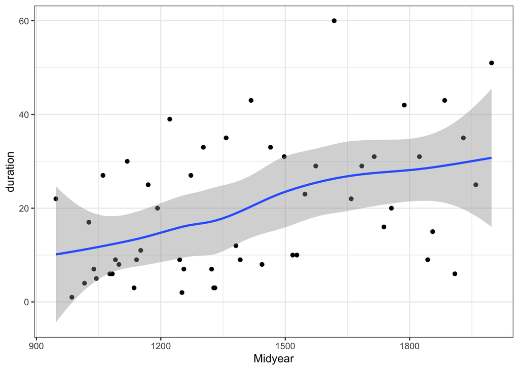

```r
# YOUR CODE
kings <- kings2

kings %>%
  mutate(duration = End_year - Start_year) %>%
  mutate(Midyear = Start_year + duration/2) %>%
  ggplot(aes(x=Midyear, y=duration)) +
  geom_point()+
  geom_smooth()+
  theme_bw()
```

And to submit this rmarkdown, knit it into html. But first, clean up the code chunks, adjust the date, rename the author and change the `eval=FALSE` flag to `eval=TRUE` so your script actually generates an output. Well done!